# griph: Graph Inference of Population Heterogeneity

Panagiotis Papasaikas, Michael Stadler and Atul Sethi

panagiotis.papasaikas@fmi.ch  
michael.stadler@fmi.ch  
atul.sethi@fmi.ch

31 August 2017

#### Abstract

griph identifies cell types in single cell RNA-seq datasets, allowing to control for unwanted sources of variance (e.g. cell cycle) that may confound the cell types. The most important function that combines all the steps of cell type identification from griph is griph_cluster. The vignette illustrates its use applied to several publicly available datasets.

#### Package

griph 0.1.1

# 1 Introduction and installation

Graph Inference of Population Heterogeneity (griph) is an R package for the analysis of single cell RNA-sequencing data. It can be used to automatically identify different cell types or states, even in the presence of confounding sources of variance such as cell cycle stages or batch effects.

griph is currently available through https://github.com. It can be installed using:

```r
library(devtools)
install_git("git://github.com/ppapasaikas/griph.git", subdir = "griph")
```

In order for griph to work, some additional packages may have to be installed. You’ll need all the ones under “Needed”. You can do without the ones under “Optional”, as they are only used in the vignette:

```
## Needed :
##   Matrix, methods, igraph, QUIC, coop, corpcor, foreach, doParallel, parallel, bigmemory, RColorBrewer, Rcpp, RcppProgress, RcppArmadillo, Matrix
## Optional :
##   BiocStyle, knitr, rmarkdown, testthat, Rtsne, gtools
```

# 2 Quickstart: A sample analysis

We will use human induced pluripotency cells from Tung et al. for this example (see details in the “Sample datasets” section). The dataset is included in the package, together with the iPS cell line labels:

```r
M <- readRDS(system.file("extdata", "tung_UMIs_top10k.rds", package = "griph"))
dim(M) # genes by cells
```

```
## [1] 10000   864
```

```r
trueLabel <- attr(M, "label2")
table(trueLabel)
```

```
## trueLabel
## NA19098 NA19101 NA19239
##     288     288     288
```

Cell types can be identified using *griph_cluster*:

```r
library(griph)
res <- griph_cluster(M, ClassAssignment = trueLabel, use.par = FALSE,
                     plot = TRUE, fsuffix = 'tung')
```

```r
table(res$MEMB)
```

```
##
##   1   2   3   4   5   6
## 102  99  94 282  98 189
```

The automatic generation of a 2D-embedding plot (`plot` argument) is switched on here and will create a png (default) or pdf (`image.format` and `fsuffix` arguments) file in the current working directory:

```r
list.files("./", pattern = "tung")
```

```
## [1] "graph_tung.png" "Lvis_tung.png"
```

The estimated cell graph (as an *igraph* object) and the coordinages of the 2D-embedding (when using `plot=TRUE`) are returned by *griph_cluster*:

```r
summary(res$GRAO) # full graph
```

```
## IGRAPH 565b5fb U-W- 864 41672 --
## + attr: class (v/c), membership (v/n), community.size (v/n), labels
## | (v/c), weight (e/n)
```

```r
head(res$plotLVis) # 2D embedding
```

```
##                         x         y
## NA19098.r1.A01 -12.422459 -12.15378
## NA19098.r1.A02 -13.228306 -11.99606
## NA19098.r1.A03  -9.097008 -12.05729
## NA19098.r1.A04 -11.683206 -15.24782
## NA19098.r1.A05 -13.078734 -12.74092
## NA19098.r1.A06 -12.846079 -14.07115
```

# 3 Visualizing *griph* results

In the graph returned by *griph_cluster*, cells are represented by graph vertices. All cells are contained in the full graph (`res$GRAO`), and a representatitve subset of cells in the simplified graph (`res$plotGRAO`), which will be generated by *plotGraph* and used for plotting. The graph can be easily plotted again, for example to separately illustrate known and predicted cell types:

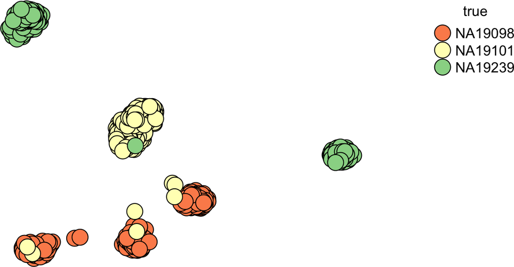

```r
g.true <- plotGraph(res, fill.type = "true", line.type = "none")
```

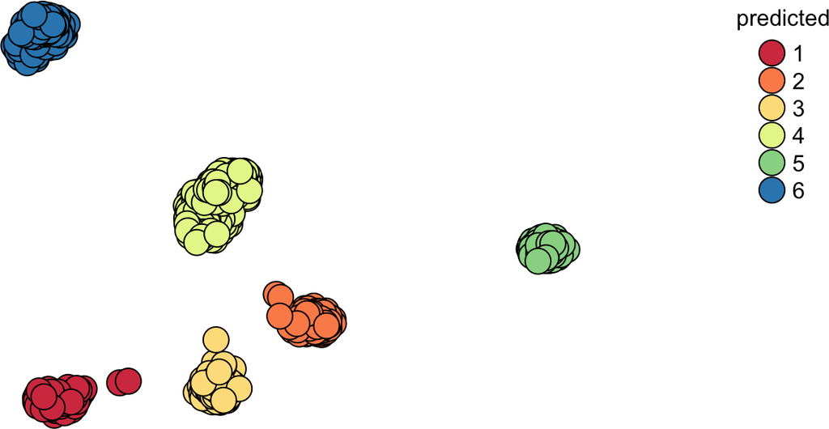

```r
res$plotGRAO <- g.true # store in res for re-use
g.pred <- plotGraph(res, fill.type = "predicted", line.type = "none")
```

In *plotGRAO*, weak edges are pruned, vertex attributes are added for visualization of predicted and known class assignments (if given) and a subset of the vertices is sampled if the graph exceeds the `maxG` argument. When `plotG` is set to `FALSE`, the *plotGRAO* component in the return value of *griph_cluster* is `NULL` and the simplified graph is generated later when necessary by *plotGraph*.

It is also possible to draw polygons around cells of each class:

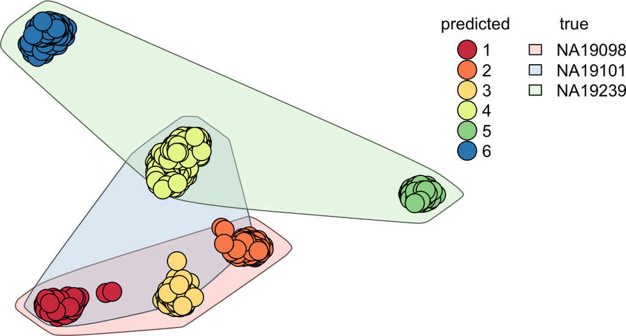

```r
g <- plotGraph(res, line.type = "none", mark.type = "true")
```

… or to collapse all the cells that are of the same class into a single vertex in the graph (maybe useful for large graphs with many predicted classes):

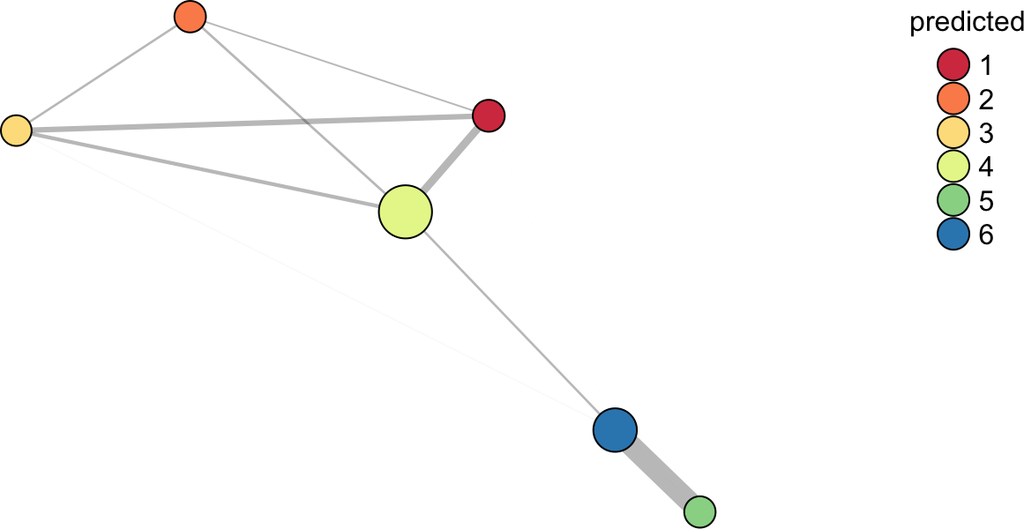

```r
g <- plotGraph(res, collapse.type = "predicted")
```

Alternatively (typically for large graph with more than 1000 cells), results can be visualized by applying a dimensionality reduction/projection technique such as t-SNE to the affinity matrix returned by *griph*:

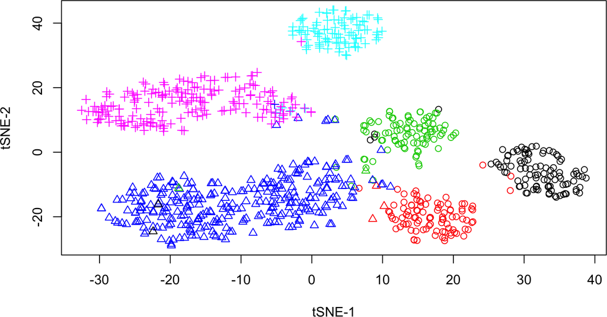

```r
library(Rtsne)
out <- Rtsne(as.dist(1-res$DISTM), pca = FALSE,
             perplexity = 5, is_distance = TRUE)
plot(out$Y, xlab="tSNE-1", ylab="tSNE-2", col=res$MEMB,
     pch=as.numeric(trueLabel))
```

or more conveniently using the wrapper function provided by `griph`:

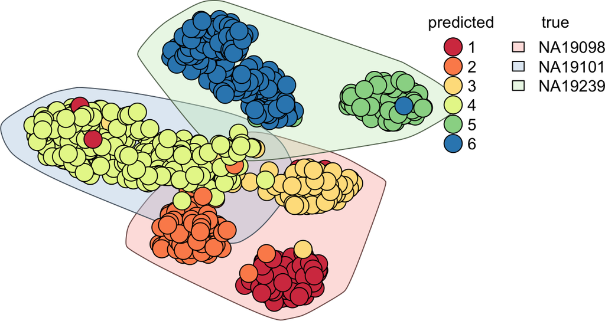

```r
plotTsne(res, fill.type = "predicted", line.type = "none", mark.type = "true",
         perplexity = 7)
```

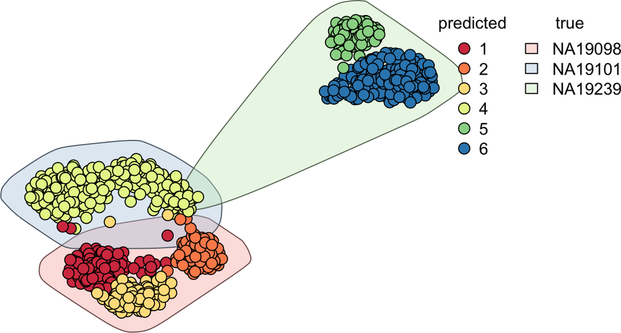

```r
plotLVis(res, fill.type = "predicted", line.type = "none", mark.type = "true")
```

Finally, the plotting functions can also map numerical or categorical values to the color of each cell. An example is to visualize the number of detected genes:

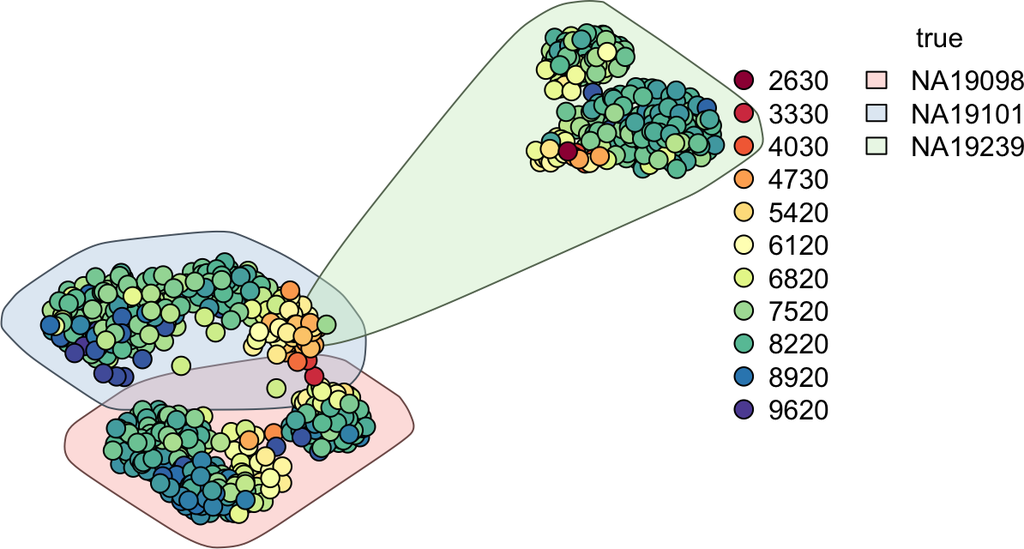

```r
plotLVis(res, fill.type = colSums(M > 0), line.type = "none", mark.type = "true")
```

# 4 Accessing the cell classification

*griph_cluster* identified 6 cell types in the data, and the confusion matrix returned in the result summarizes how they relate to the known cell types or states:

```r
res$ConfMatrix # confusion matrix
```

```
##          true
## predicted NA19098 NA19101 NA19239
##         1     100       2       0
##         2      96       3       0
##         3      92       2       0
##         4       0     281       1
##         5       0       0      98
##         6       0       0     189
```

When comparing different classifications with each other, they may differ in granularity, yet be consistent with each other. This can be seen for example in the confusion matrix above where for example *NA190998* cells are found in multiple predicted classes. *griph* calculates the classification error by assigning each identified class to the major known class (for example *NA19098* for predicted class *2*) and only counting the 3 cells in *2* as wrongly classified that are not *NA19098*:

```r
res$miscl # misclassification error
```

```
## [1] 0.009259259
```

# 5 Sample datasets included in this package

## 5.1 Buettner et al., Nature Biotechnology 2015

Computational analysis of cell-to-cell heterogeneity in single-cell RNA-sequencing data reveals hidden subpopulations of cells. Buettner F, Natarajan KN, Casale FP, Proserpio V, Scialdone A, Theis FJ, Teichmann SA, Marioni JC, Stegle O. Nat Biotechnol. 2015 Feb;33(2):155-60. doi: 10.1038/nbt.3102.

- Description: 288 mouse ES cells (Fluidigm C1), classified into three cell cycle stages
- PubMed: http://www.ncbi.nlm.nih.gov/pubmed/25599176
- DOI: https://doi.org/10.1038/nbt.3102
- Data: http://www.ebi.ac.uk/arrayexpress/experiments/E-MTAB-2805/
- Filtering: all cells, top 10,000 genes

```r
fname <- system.file("extdata", "buettner_top10k.rds", package = "griph")
M <- readRDS(fname)
dim(M)
```

```
## [1] 10000   288
```

```r
label <- attr(M, "label")
table(label)
```

```
## label
##  G1 G2M   S
##  96  96  96
```

## 5.2 Kolodziejczyk et al., Cell Stem Cell 2015

Single Cell RNA-Sequencing of Pluripotent States Unlocks Modular Transcriptional Variation. Kolodziejczyk AA, Kim JK, Tsang JC, Ilicic T, Henriksson J, Natarajan KN, Tuck AC, Gao X, Bühler M, Liu P, Marioni JC, Teichmann SA. Cell Stem Cell. 2015 Oct 1;17(4):471-85. doi: 10.1016/j.stem.2015.09.011.

- Description: 704 mouse ES cells (Fluidigm C1), three culture conditions: serum + LIF (lif), 2i + LIF (2i) and alternative 2i + LIF (a2i)
- PubMed: https://www.ncbi.nlm.nih.gov/pubmed/26431182
- DOI: https://doi.org/10.1016/j.stem.2015.09.011
- Data: http://www.ebi.ac.uk/arrayexpress/experiments/E-MTAB-2600/, http://www.ebi.ac.uk/teichmann-srv/espresso
- Filtering: all cells, top 10,000 genes

```r
fname <- system.file("extdata", "kolodziejck_top10k.rds", package = "griph")
M <- readRDS(fname)
dim(M)
```

```
## [1] 10000   704
```

```r
label <- attr(M, "label")
table(label)
```

```
## label
## lif  2i a2i
## 250 295 159
```

## 5.3 Usoskin et al., Nat Neurosci. 2015

Unbiased classification of sensory neuron types by large-scale single-cell RNA sequencing. Usoskin D, Furlan A, Islam S, Abdo H, Lönnerberg P, Lou D, Hjerling-Leffler J, Haeggström J, Kharchenko O, Kharchenko PV, Linnarsson S, Ernfors P. Nat Neurosci. 2015 Jan;18(1):145-53. doi: 10.1038/nn.3881.

- Description: 799 mouse cells (622 neurons) from lumbar DRGs (custom protocol), different sensory neuron subtypes
- PubMed: https://www.ncbi.nlm.nih.gov/pubmed/25420068
- DOI: https://doi.org/10.1038/nn.3881
- Data: https://www.ncbi.nlm.nih.gov/geo/query/acc.cgi?acc=GSE59739
- Filtering: all cells, top 10,000 genes

```r
fname <- system.file("extdata", "usoskin_top10k.rds", package = "griph")
M <- readRDS(fname)
dim(M)
```

```
## [1] 10000   799
```

```r
label <- attr(M, "label")
table(label)
```

```
## label
## Central, unsolved                NF        NF outlier               NoN
##                39               139                 9               109
##       NoN outlier                NP               PEP                TH
##                 2               169                81               233
##        TH outlier
##                18
```

```r
label2 <- attr(M, "label2")
table(label2)
```

```
## label2
## Central, unsolved               NF1             NF2/3             NF4/5
##                39                31                60                48
##        NF outlier               NoN       NoN outlier               NP1
##                 9               109                 2               125
##               NP2              PEP1              PEP2                TH
##                44                64                17               233
##        TH outlier
##                18
```

```r
label3 <- attr(M, "label3")
table(label3)
```

```
## label3
## Central, unsolved               NF1               NF2               NF3
##                39                31                48                12
##               NF4               NF5        NF outlier               NoN
##                22                26                 9               109
##       NoN outlier               NP1               NP2               NP3
##                 2               125                32                12
##              PEP1              PEP2                TH        TH outlier
##                64                17               233                18
```

## 5.4 Zeisel et al., Science 2015

Brain structure. Cell types in the mouse cortex and hippocampus revealed by single-cell RNA-seq. Zeisel A, Muñoz-Manchado AB, Codeluppi S, Lönnerberg P, La Manno G, Juréus A, Marques S, Munguba H, He L, Betsholtz C, Rolny C, Castelo-Branco G, Hjerling-Leffler J, Linnarsson S. Science. 2015 Mar 6;347(6226):1138-42. doi: 10.1126/science.aaa1934.

- Description: 3005 mouse brain cells (Fluidigm C1), different neuron subtypes
- PubMed: https://www.ncbi.nlm.nih.gov/pubmed/25700174
- DOI: https://doi.org/10.1126/science.aaa1934
- Data: http://linnarssonlab.org/cortex/, https://www.ncbi.nlm.nih.gov/geo/query/acc.cgi?acc=GSE60361
- Filtering: all cells, top 10,000 genes

```r
fname <- system.file("extdata", "zeisel_top10k.rds", package = "griph")
M <- readRDS(fname)
dim(M)
```

```
## [1] 10000  3005
```

```r
label <- attr(M, "label")
table(label)
```

```
## label
## astrocytes_ependymal    endothelial-mural         interneurons
##                  224                  235                  290
##            microglia     oligodendrocytes        pyramidal CA1
##                   98                  820                  939
##         pyramidal SS
##                  399
```

```r
label2 <- attr(M, "label2")
table(label2)
```

```
## label2
##    Astro1    Astro2   CA1Pyr1   CA1Pyr2 CA1PyrInt   CA2Pyr2   Choroid
##        68        61       380       447        49        41        10
##   ClauPyr     Epend      Int1     Int10     Int11     Int12     Int13
##         5        20        12        21        10        21        15
##     Int14     Int15     Int16      Int2      Int3      Int4      Int5
##        22        18        20        24        10        15        20
##      Int6      Int7      Int8      Int9      Mgl1      Mgl2    (none)
##        22        23        26        11        17        16       189
##    Oligo1    Oligo2    Oligo3    Oligo4    Oligo5    Oligo6     Peric
##        45        98        87       106       125       359        21
##      Pvm1      Pvm2   S1PyrDL  S1PyrL23   S1PyrL4   S1PyrL5  S1PyrL5a
##        32        33        81        74        26        16        28
##   S1PyrL6  S1PyrL6b    SubPyr     Vend1     Vend2      Vsmc
##        39        21        22        32       105        62
```

## 5.5 Tung et al., Sci Rep 2017

Batch effects and the effective design of single-cell gene expression studies. Po-Yuan Tung, John D. Blischak, Chiaowen Joyce Hsiao, David A. Knowles, Jonathan E. Burnett, Jonathan K. Pritchard & Yoav Gilad. Scientific Reports 7, Article number: 39921 (2017). doi:10.1038/srep39921.

- Description: 864 human iPS cells (Fluidigm C1), three individuals, three C1 chip replicates for each individual
- PubMed: https://www.ncbi.nlm.nih.gov/pubmed/28045081
- DOI: http://dx.doi.org/10.1038/srep39921
- Data: http://www.ncbi.nlm.nih.gov/geo/query/acc.cgi?acc=GSE77288, https://github.com/jdblischak/singleCellSeq
- Filtering: all cells, top 10,000 genes

```r
fname <- system.file("extdata", "tung_UMIs_top10k.rds", package = "griph")
M <- readRDS(fname)
dim(M)
```

```
## [1] 10000   864
```

```r
label <- attr(M, "label")
table(label)
```

```
## label
## NA19098.r1 NA19098.r2 NA19098.r3 NA19101.r1 NA19101.r2 NA19101.r3 NA19239.r1
##         96         96         96         96         96         96         96
## NA19239.r2 NA19239.r3
##         96         96
```

```r
label2 <- attr(M, "label2")
table(label2)
```

```
## label2
## NA19098 NA19101 NA19239
##     288     288     288
```